# Probability Distributions, Precision, Repeatability, Reproducibility (Stability), and Comparisons

Module 05

Ray J. Hoobler

## Libraries

```r
library(tidyverse)
library(ggtext)
library(ggridges)
library(latex2exp)
```

# Probability Distributions

## Why Do We Care?

- We can visualize a population based on given parameters
- We can use probability distributions to calculate **confidence intervals** for descriptive statistics
  - and extend this to the calculation of critical regions to perform hypothesis testing
- Compare our data against a given distribution (i.e., is a parameter in our data *normally* distributed or follow another distribution)
- Use distributions to create example datasets

# Discrete versus Continuous Distributions

## Discrete

1. The probability that $x$ has a discrete value is $p(x)$
2. $p(x)$ is positive (or non-negative for all real values of $x$)
3. For all possible $j$ values of x,

$$\sum_j p_j = 1$$

- Discrete probability functions is more accurately described as a *probability mass function*.
- Examples include the *binomial* and *poisson* distributions

## Continuous

1. The probability of $x$ between two points is given by a function $f(x)$

$$p[a \le x \le b] = \int_a^b f(x) dx$$

2. $p[a \le x \le b]$ is positive (or non-negative for all real values of $x$)
3. The integral over all values is equal to 1

$$\int_{-\infty}^{\infty} f(x)dx = 1$$

- The probability at a single point is 0, so remember, continous distributions are measured over an interval (the area under the curve).
- Continuous probability functions are more accurately described as *probability density functions*.
- We will focus on continuous distribution functions for this section

# Distributions

## Continuous Distributions

- Normal Distribution
- Uniform Distribution
- *t* Distribution
- F Distribution
- Chi-Square Distribution
- See the [NIST e-Handbook for a larger list](https://www.itl.nist.gov/div898/handbook/eda/section3/eda366.htm)

## The Normal Distribution Created Using ggplot

Looks like?

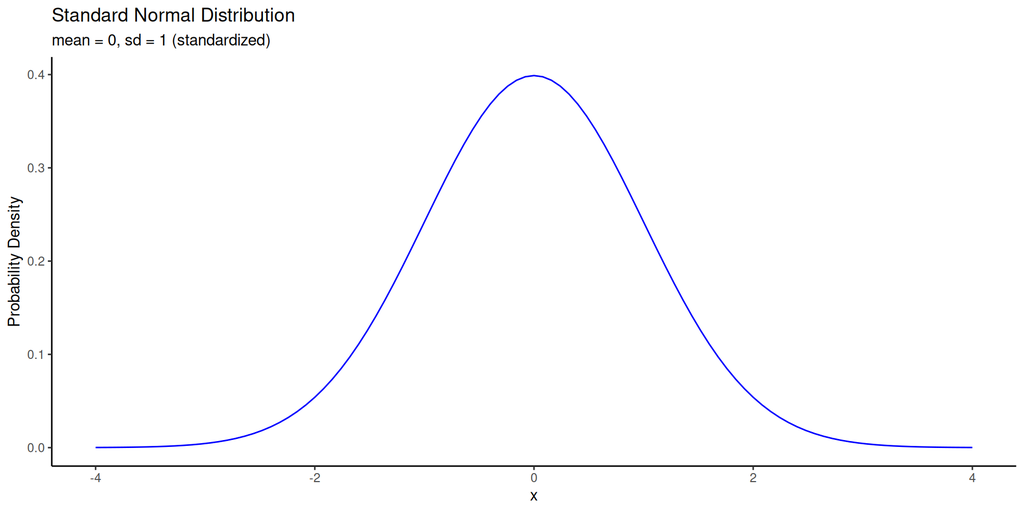

```r
tibble(x = c(-4, 4)) %>%
         ggplot() +
         stat_function(mapping = aes(x = x),
                       fun = dnorm,
                       args = list(mean = 0, sd = 1),
                       color = "blue") +
  labs(
    title = "Standard Normal Distribution",
    subtitle = "mean = 0, sd = 1 (standardized)",
    y = "Probability Density"
  ) +
  theme_classic()
```

## The normal distribution with a non-zero mean and a sd $\ne 1$

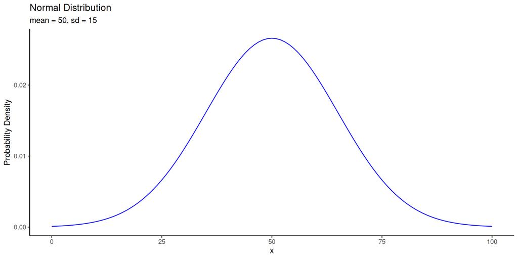

```r
tibble(x = c(0, 100)) %>%
         ggplot() +
         stat_function(mapping = aes(x = x),
                       fun = dnorm,
                       args = list(mean = 50, sd = 15),
                       color = "blue") +
  labs(
    title = "Normal Distribution",
    subtitle = "mean = 50, sd = 15",
    y = "Probability Density"
  ) +
  theme_classic()
```

## Comments on the Normal Distribution

[NIST e-Handbook](https://www.itl.nist.gov/div898/handbook/eda/section3/eda3661.htm)

For both theoretical and practical reasons, the normal distribution is probably the most important distribution in statistics. For example,

- Many classical statistical tests are based on the assumption that the data follow a normal distribution. This assumption should be tested before applying these tests.
- In modeling applications, such as linear and non-linear regression, the error term is often assumed to follow a normal distribution with fixed location and scale.
- The normal distribution is used to find significance levels in many hypothesis tests and confidence intervals.

## Uniform Distribution?

## Unniform Distribution

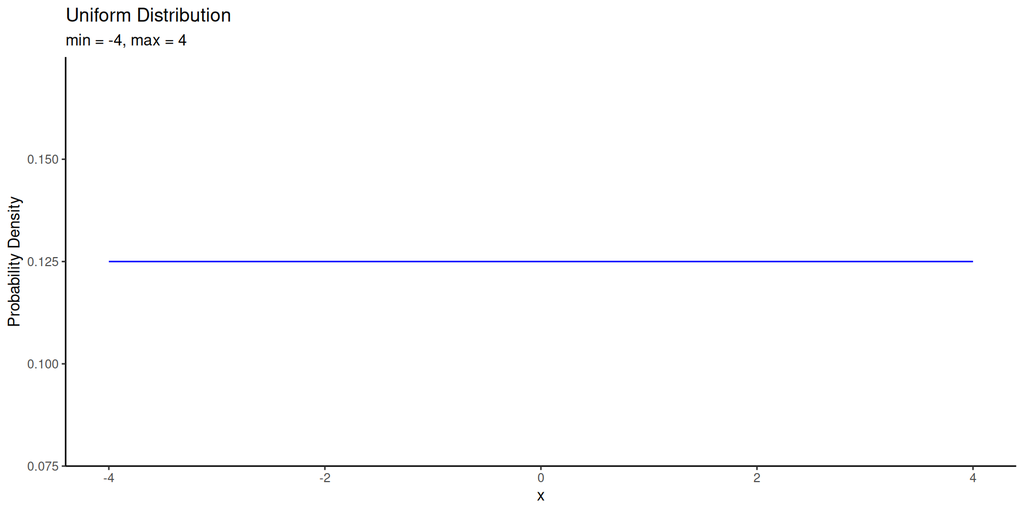

```r
tibble(x = c(-4, 4)) %>%
         ggplot() +
         stat_function(mapping = aes(x = x),
                       fun = dunif,
                       args = list(min = -4, max = 4),
                       color = "blue") +
  labs(
    title = "Uniform Distribution",
    subtitle = "min = -4, max = 4",
    y = "Probability Density"
  ) +
  theme_classic()
```

## Comments on the Uniform Distribution

[NIST e-Handbook](https://www.itl.nist.gov/div898/handbook/eda/section3/eda3662.htm)

The uniform distribution defines equal probability over a given range for a continuous distribution. For this reason, it is important as a reference distribution.

One of the most important applications of the uniform distribution is in the generation of random numbers. That is, almost all random number generators generate random numbers on the (0,1) interval. For other distributions, some transformation is applied to the uniform random numbers.

## t Distribution

In theory, requires multiple parameters to define:  
- **location** (mean)  
- **scale** (standard deviation)  
- **shape** (degrees of freedom, df)

But, we will always refer back to a “standardized” distribution curve centered at zero.

(Notice how quickly we approach a normal distribution.) . . .

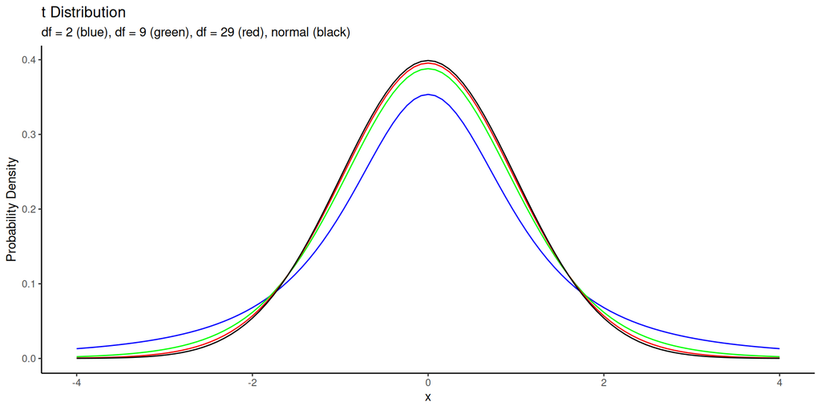

```r
tibble(x = c(-4, 4)) %>%
  ggplot() +
  stat_function(mapping = aes(x = x),
                fun = dt,
                args = list(df = 2), color = "blue") +
  stat_function(mapping = aes(x = x),
                fun = dt,
                args = list(df = 9), color = "green") +
  stat_function(mapping = aes(x = x),
                fun = dt,
                args = list(df = 29), color = "red") +
  stat_function(mapping = aes(x = x),
                fun = dnorm,
                args = list(mean = 0, sd = 1), color = "black") +
  labs(
    title = "t Distribution",
    subtitle = "df = 2 (blue), df = 9 (green), df = 29 (red), normal (black)",
    y = "Probability Density"
  ) +
  theme_classic()
```

## Comments on the t Distribution

[NIST e-Handbook](https://www.itl.nist.gov/div898/handbook/eda/section3/eda3664.htm)

The t distribution is used in many cases for the critical regions for hypothesis tests and in determining confidence intervals. The most common example is testing if data are consistent with the assumed process mean.